# Model 3

## Model definition:

### States

|  | $A$ | $Sn$ | $Sp$ |
| --- | --- | --- | --- |
| TB-related symptoms | No | Yes | Yes |
| Care-seeking intentions | No | Yes | Yes |
| TB-related mortality | No | Yes | Yes |
| Sputum smear microscopy | Usually low precision | Negative | Positive |

- $A$: Asymptomatic TB
- $Sn$: Symptomatic TB, smear-negative
- $Sp$: Symptomatic TB, smear-positive

### Dynamics

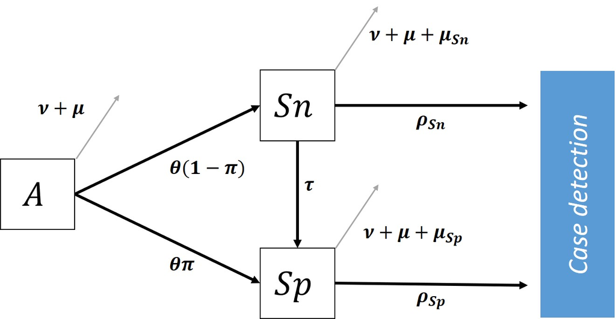

Subject to a **Steady-declining solution** where the annual decline rates: prevalence = incidence = notification = $\phi$

## Empirical model

### Prevalence

We related the prevalence, $Prev_A$, $Prev_{Sn}$ and $Prev_{Sp}$, to prevalence survey data with the $Binomial$ distribution, where

$$\begin{array}{rl}
P0_{Sn} &= (1 - \pi) \theta / (\tau + \gamma_{Sn} + \rho_{Sn} - \phi) \\
P0_{Sp} &= (\pi \theta + \tau P0_{Sn}) / (\gamma_{Sp} + \rho_{Sp} - \phi) \\
Prev_A &= \frac{1}{1 + P0_{Sn} + P0_{Sp}} \times Prev \\
Prev_{Sn} &= \frac{P0_{Sn}}{1 + P0_{Sn} + P0_{Sp}} \times Prev \\
Prev_{Sp} &= \frac{P0_{Sp}}{1 + P0_{Sn} + P0_{Sp}} \times Prev
\end{array}$$

- $Prev$: the prevalence of all active TB.

### Notification

We related the time-series of case notification rates, $CNR_{Sn, t}$ and $CNR_{Sp, t}$, to case-notification and demographic data with the $Poisson$ distribution, where

$$CNR_{Sn, t} = \rho_{Sn} Prev_{Sn} \times e^{-\phi (t - t0)}$$
$$CNR_{Sp, t} = \rho_{Sp} Prev_{Sp} \times e^{-\phi (t - t0)}$$

- $t$: year
- $t0$: the year with the prevalence survey

### Prior distribution

| Parameter | Distribution |  |
| --- | --- | --- |
| $\theta$ | $invGamma(1, 1)$ |  |
| $\pi$ | $U(0, 1)$ |  |
| $\tau$ | $U(0, 0.5)$ |  |
| $\rho_{Sn$ | $invGamma(1, 1)$ |  |
| $\rho_{Sp}$ | $invGamma(1, 1)$ |  |
| $\nu$ | $U(0.1, 0.3)$ |  |
| $\phi$ | $U(-0.2, 0.2)$ |  |
| $Prev$ | $U(0, 1)$ |  |

The model fitting were implemented `R` with `rstan`.

#### Notations

- $\theta$: Symptom onset rate
- $\pi$: Proportion of smear-positive at symptom onset
- $\tau$: Conversion rate, from smear-negative to -positive
- $\rho_{Sn}$: Care-seeking rate of state $Sn$
- $\rho_{Sp}$: Care-seeking rate of state $Sp$
- $\nu$: Self-cure rate
- $\mu$: Background death rate
- $\mu_{Sn}$: Untreated death rate of state $Sn$
- $\mu_{Sp}$: Untreated death rate of state $Sp$
- $\phi$: Annual decline rate for incidence/prevalence/notification
- $\gamma_A = \nu + \mu$: Dropout rate of $A$ (self-cure + death)
- $\gamma_{Sn} = \nu + \mu + \mu_{Sn}$: Dropout rate of $Sn$ (self-cure + death)
- $\gamma_{Sp} = \nu + \mu + \mu_{Sp}$: Dropout rate of $Sp$ (self-cure + death)